# Lab 1: Introduction to R and RStudio

The goal of this lab is to introduce you to R and RStudio, which you’ll be using throughout the course both to learn the statistical concepts discussed in the course and to analyze real data and come to informed conclusions. To clarify which is which: `R` is the name of the programming language itself and RStudio is a convenient interface for working with `R` . Think of it like this:

- R is like a car’s engine,
- RStudio is like a car’s dashboard

[figure not shown]

This means that you will be working directly in the RStudio environment: all the menu points, typing and coding runs in RStudio. But the engine that performs the calculations is R, which will remain most of the time outside of view.

We will be using a cloud version of RStudio, to do this, follow the steps below:

- Use a link provided to connect to posit cloud.
- Sign up with your RUG Google account
- Click on “Lab 01: Introduction to R and RStudio”

You should see a window that looks more or less like the image shown below.

[figure not shown]

- **Panel (1)** on the left is where the action *happens. This panel is called the* console* or sometomes the *command window*. Every time you launch RStudio, it will have the same text at the top of the console telling you the version of R that you’re running.
  - Below that information is the *prompt*, indicated by the `>` symbol. As its name suggests, this prompt is really a request for a command. Initially, interacting with `R` is all about typing commands and interpreting the output. In a sense, this is the most important window, because this is where R actually does stuff.
  - Instead of a single pane, the left side of the screen can contain two panes: a *console* (on the bottom) and a *script window* at the top. The script window can contain a batch of printed commands (scripts), which you can edit and save. If you cannot see this window, you can open it by clicking on `File` 👉 `New` `R script`. Just typing a command in the editor window does not run it. The command must get into the command window before R executes the command. If you want to run a line from the script window (or the whole script), you can click Run or press CTRL+ENTER to send it to the command window.
- **Panel (2)** in the upper right contains your *environment* as well as a history of the commands that you’ve previously entered.
- **Panel (3)** in the lower right contains tabs for browse the *files* in your project folder, access *help* files for `R` functions, install and manage `R` *packages*, and inspecting visualizations. By default, all data visualizations you make will appear directly below the code you used to create them.

Before starting, we recommend that you configure your RStudio environment with the follwoing global options First, go to the menu point `Tools` 👉 `Global Options`. Then make sure the following checkboxes are left **unchecked**.

- In the `General` panel, the three `restore` options are unchecked,
- In the same panel, all checkboxes in the `History` section are unchecked, and the `Save workspace to .RData on exit` is set to `Never`.
- In the `R Markdown` panel, check that the `Show output inline` is also unchecked.
- Finally, under `Code` 👉 `Display` 👉 `Syntax` check `Use rainbow parantheses`.

[figure not shown]

### R Packages

`R` is an open-source programming language, meaning that users can contribute packages that make our lives easier, and we can use them for free. For this lab we will use the **tidyverse** an “umbrella” package which houses a suite of many different `R` packages: for data wrangling and data visualization

In the lower right hand corner click on the *Packages* tab. Type the name of each of these packages (tidyverse, openintro) into the search box to see if they have been installed.

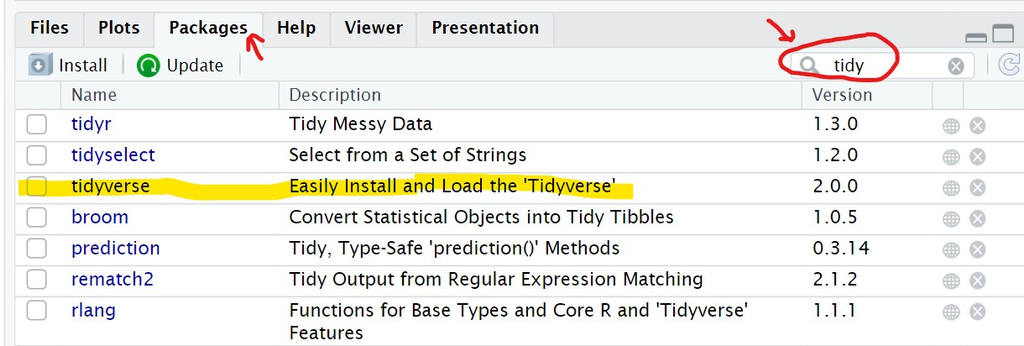

If your package does not appear when you type its name, you will need to install the missing package by typing the following line of code into the console of your RStudio session. Be sure to press enter/return after each line of code.

```r
install.packages("tidyverse")
```

You only need to *install* packages once, but you need to *load* them each time you relaunch RStudio. We load packages with the `library` function. Type the the following line in your console to load the tidyverse package into your working environment.

```r
library(tidyverse)
```

We are choosing to use the tidyverse package because it will help us with loading data, wrangling, visualizing and analyzing it. You can find more about the packages in the tidyverse at [tidyverse.org](http://tidyverse.org/).

### Creating a reproducible lab report

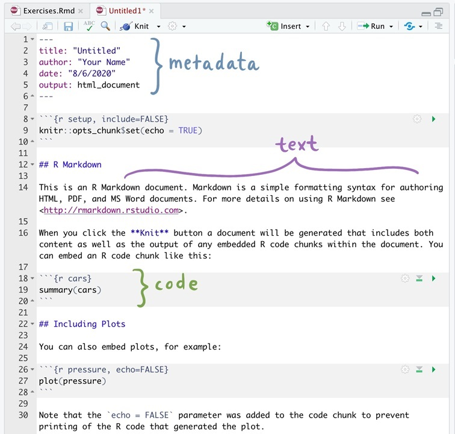

- **The YAML:** This is the header of the file, and it includes the file’s meta-data: information about the appearance of the final report. Go ahead and put your name(s) in the YAML in the appropriate place.
- **The Markdown:** This is the formatted text that goes into the report, and is like the text you would write in a word document, for example
- **The code chunks:** In an R Markdown file, `R` code appears in a gray box, which we call “code chunks.” The R Markdown file knows that the gray box contains `R` code because it begins with three tick marks (```), followed by two curly braces that contain a lowercase letter r ({r}).

To answer the first exercise please consult with the [quarto markdown cheatsheet](https://quarto.org/docs/authoring/markdown-basics.html).

1. Knit your RMarkdown file and observe the result in the form of a knitted report. Now change the following in your RMarkdown (a) In the YAML, identify the author’s name and replace it with **your** name. (b) Replace the date to show **today’s date**. (c) Identify the sentence “The lab specifications can be found here,” and turn the word “here” [into a link](https://quarto.org/docs/authoring/markdown-basics.html#links-images), (d) [Add an image](https://quarto.org/docs/authoring/figures.html) of the car dashboard (a metaphor for RStudio) and the car engine (a metaphor for R).

One of the features of R Markdown files is that they allow for us to embed our `R` code within a written report.

Instead of typing our `R` code into the console, we encourage you to type any code you want to save in the `R` code chunk associated with each problem. You can execute the `R` code you type in these code chunks similar to how you typed code into the console and pressed enter/return. Within the code chunk there are a few ways to execute lines of `R` code:

- For a single line, place your cursor on the line on code and press `Ctrl-Enter` or `Cmd-Enter` at the same time, or
- Alternatively, place your cursor on the line and press the “Run” button in the upper right hand corner of the R Markdown file.

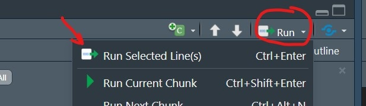

- If you wanted to run all of the `R` code in a given code chunk, you can click on the “Play” button in the upper right hand corner of the code chunk (green sideways triangle).

If at any point you need to start over and run all of the code chunks before a specific code chunk, you click on the “Fastforward” button in the upper right hand corner of that code chunk (gray upside down triangle with a bar below). This will run every code chunk that occurred *before* that code chunk, but *will not* execute the `R` code included in that code chunk.

## Basic syntax in R

In R, there are several types of single value items, such as: logical, numeric and character. For example,

- TRUE or FALSE are logical
- 1, 2, 3 … are numeric
- a, b, c … are character

This is pretty self-explanatory, but there are other data types we will investigate later, most notibly the factor data type, which allows you to define a categorical variable, such as gender (levels: female, male), or directions (levels: north, south, east, west).

### Vectors

The term vector in R is a bit different from the traditional sense of vector in math. It stands for a list of items that are the same type, i.e., a list that is all numeric, or all character, but not mixed.

To create a vector, you use the `c()` command. For example, I want to create a vector of 1, 2, 3, the code will be

```r
c(1, 2, 3)
```

Now, to save my vector (or anything) as an R item, you will use the `<-` syntax. This is called the left arrow. Let’s say we are saving this vector of c(1, 2, 3) as an item called `a` then

```r
a <- c(1, 2, 3)
```

When you run this, something happens. If you look at the environment at the upper right, you should see ‘a’ shows up as a saved item. Remember to use a different name for different items. If you save them as the same name, the later item will just overwrite the previous.

Say I want a vector consists of apple, banana, and orange, and save it as an item named `b`, what do I do?

```r
b <- c("apple", "banana", "orange")
b
```

```
## [1] "apple"  "banana" "orange"
```

Note that apple, banana and orange all have to be in quotes `" "`. The quotes `" "` specify the terms apple, banana or oranges are characters, not items in the environment. Forgetting to use quotes is a very common source of bugs.

### Subsetting vectors

Say if you want to select a member of a vector by position, you will use the square bracket `[ ]` syntax. Say I want the 2nd member in vector `a`, the code will be

```r
a[2]
```

```
## [1] 2
```

If I want anything but the 2nd member, it will be

```r
a[-2]
```

```
## [1] 1 3
```

If I want the 1st and 2nd member, it will be

```r
a[c(1, 2)]
```

```
## [1] 1 2
```

If I want anything but the 1st and 2nd member, it will be

```r
a[-c(1, 2)]
```

```
## [1] 3
```

You don’t have to memorize how to do anything. If you ever get confused, you can always go look at the base R cheat sheet.

### Matrix

Matrix is rectangular data that is all the same type, e.g., all numeric.  
For example, if I want a matrix like this:

1 | 2 | 3 | 4 |  
1 | 2 | 1 | 2 |  
2 | 3 | 2 | 4 |

What do I do? An easy way to do is combining different vectors.

```r
my_matrix <- rbind(
  c(1, 2, 3, 4),
  c(1, 2, 1, 2),
  c(2, 3, 2, 4)
)

my_matrix
```

The `rbind()` command takes vectors of the same length, and bind them as rows. The matrix has 3 rows, so I bind 3 vectors together. (Note: there is a `cbind()` command, which binds vectors as columns.)

### Data frame

The last type of items I will cover today is data frame. Data frame is the technical jargon for data tables in R. We will cover data frames more in depth in the next lesson. Today we will just have a brief introduction.

Say I have 3 apples, 4 banana and 2 oranges, and I want to organize this info into a table, and called this table fruits. What do I do?

```r
fruits <- data.frame(
  name = c("apple", "banana", "orange"),
  count = c(3, 4, 2)
)

fruits
```

```
##     name count
## 1  apple     3
## 2 banana     4
## 3 orange     2
```

To make a new table, you can use the `data.frame()` command. Inside `data.frame()`, you then type out each columns as vectors. In this example, the columns are name and count.

Notice that in a data frame, all members of a column are the same type. For example, the count column is all numeric.

This is different from a matrix, because in a matrix, all members are the same type across rows and columns. Also notice data frames have column names. In this case, the column names are name and count.

You can pull out a particular column using its name. For example, say I want to pull out the count column, what do I do?

You will use the `$` syntax.

```r
fruits$count
```

```
## [1] 3 4 2
```

If I want the name column, it would be `fruits$name` instead.

### Operations

Now let’s go over some basic operations. Say I want to add 0.5 to each member of my matrix, then take the log2 of each member then take the square root, what do I do?

```r
sqrt(log2(my_matrix + 0.5))
```

See, nothing complicated, just an interactive calculator. You see how the parentheses of `log2()` and `sqrt()` are nested. You can imagine if you do this for many steps, there will be too many parentheses to keep track of. To avoid the too many nested parentheses problem, you can use the pipe syntax.

The pipe is `%>%`

The shortcut is Ctrl+Shift+M on a PC and Cmd+Shift+M on a Mac. I think Ctrl+Shift+M also works on a Mac. When you use the pipe, it takes the output of the previous line and feed it as the input for the next line. In our example, it should look like:

```r
(my_matrix + 0.5) %>%
  log2() %>%
  sqrt()
```

See how this is much clearer and easier to read than nested parentheses?

It’s a good practice to start a new line after `%>%`, which makes your code easier to read.

`%>%` is a good trick.

Missing parentheses is another common source of bugs, and `%>%` really reduces that.

### Add comments

Sometimes it’s nice to annotate your code in-line as well. The way to do it is using the `#` symbol in the code chunk. Any text on the same line after a `#` sign will be ignore in a code chunk by R. For example:

```r
(my_matrix + 0.5) %>% #add 0.5 to every value first
  log2() %>% #then take log2()
  sqrt() #lastly take square root
```

If you add the `#` sign at the very start of the line, it will skip that entire line.

```r
c(4, 4, 4) %>%
  # log2() %>%
  # mean() %>%
  sqrt()
```

This is helpful when you realize you want to skip a step (or steps), but you don’t want to remove the code.

You can simply add a `#` sign to the start of the lines that you want to skip, and R will ignore them. The shortcut is `Ctrl+Shift+C` on a PC and `Cmd+Shift+C` on a Mac.

2. Insert a new code chunk and create a matrix as shown below. Save it as an object called `my_mat2`. Now do the following: (a) Take the square root for each member of `my_mat2`, then take `log2()`, and (b) lastly find the maximum value (use the pipe syntax. The command for maximum is `max()`)

   ```
                     | 1 | 1 | 2 | 2 |
                     | 2 | 2 | 1 | 2 |
                     | 2 | 3 | 3 | 4 |
                     | 1 | 2 | 3 | 4 |
   ```

3. Use the following info to make a data frame and save it as an item called “grade”. Now pull out the column with the scores. Use the `$` syntax.

> Adel got 85 on the exam, Bren got 83, and Cecil got 93. Their letter grades are B, B, and A, respectively. (Hint: How many columns do you have to have?)

## The Arbuthnot dataset

The Arbuthnot data set can be loaded into your environment and then explored, manipulated and visualized using the `read_csv` function. The data is stored in an object we call `arbuthnot`. We store the data in our new object by using an ⬅️.

```r
arbuthnot <- read_csv("data/arbuthnot.csv")
```

Again, you can run the code above by:

- placing your cursor on the line and pressing `Ctrl-Enter` or `Cmd-Enter`
- placing your cursor on the line and pressing the “Run” button in the upper right hand corner of the R Markdown file, or
- by clicking on the green arrow at the top right hand corner of the code chunk

The single line of code included in this code chunk instructs `R` to load some data: the Arbuthnot baptism counts for boys and girls. You should see that the *Environment* tab in the upper right hand corner of the RStudio window now lists a data set called `arbuthnot` that has 82 observations on 3 variables.

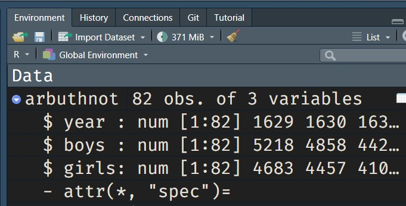

[figure not shown]

The Arbuthnot data set refers to the work of [Dr. John Arbuthnot](https://en.wikipedia.org/wiki/John_Arbuthnot), an 18<sup>th</sup> century physician, writer, and mathematician. He was interested in the ratio of newborn boys to newborn girls, so he gathered the baptism records for children born in London for every year from 1629 to 1710.

We can view the data by running the code below or by typing the name of the dataset into the console. Be careful the spelling and capitalization you use! `R` is case sensitive, so if you accidentally type `Arbuthnot` `R` will tell you that object cannot be found.

```r
arbuthnot
```

This command displays the data for us, however, printing it in the console is not always useful. One advantage of RStudio is that it comes with a built-in data viewer. The *Environment* tab (in the upper right pane) lists the objects in your environment.

Clicking on the name `arbuthnot` will open up a *Data Viewer* tab next to your R Markdown file, which provides an alternative display of the data set. Once you are done viewing the data, You can close this tab by clicking on the `x` in the upper left hand corner.

When inspecting the data, you should see four columns of numbers and 82 rows. Each row represents a different year that Arbuthnot collected data. The first entry in each row is the row number, the second is the year, and the third and fourth are the numbers of boys and girls baptized that year, respectively. Use the scrollbar on the right side of the console window to examine the complete data set.

You can see the dimensions of this data frame (number of rows and columns) as well as the names of the variables and the first few observations by inserting the name of the dataset into the `glimpse()` function, as seen below:

```r
glimpse(arbuthnot)
```

Although we previously said that it is best practice to type all of your `R` code into the code chunk, it is better practice to type this command into your console. Generally, you should type all of the code that is necessary for your solution into the code chunk. Because this command is used to explore the data, it is not necessary for your solution code and **should not** be included in your solution file.

This command should output the following:

```
## Rows: 82
## Columns: 3
## $ year  <dbl> 1629, 1630, 1631, 1632, 1633, 1634, 1635, 1636, 1637, 1638, 1639…
## $ boys  <dbl> 5218, 4858, 4422, 4994, 5158, 5035, 5106, 4917, 4703, 5359, 5366…
## $ girls <dbl> 4683, 4457, 4102, 4590, 4839, 4820, 4928, 4605, 4457, 4952, 4784…
```

We can see that there are 82 observations and 3 variables in this dataset. The variable names are `year`, `boys`, and `girls`. At this point, you might notice that many of the commands in `R` look a lot like functions from math class; that is, invoking `R` commands means supplying a function with some number of inputs (what are called arguments) which the function uses to produce an output. The `glimpse()` command, for example, took a single argument, the name of a data frame and produced a display of the dataset as an output.

4. Load the `tidyverse` library into your environment, and then load the `arbuthnot` dataset. Now use the `glimpse` function to display its content, and the `dim` function to display its dimensions. Write down the variables associated with the dataset and the number of observations in your dataset.

## Data Exploration

Let’s start to examine the data a little more closely. We can access the data in a single column of a data frame by extracting the column with a `$`. For example, the code below extracts the `boys` column from the `arbuthnot` data frame.

```r
arbuthnot$boys
```

This command will only show the number of boys baptized each year. `R` interprets the `$` as saying “go to the data frame that comes before me, and find the variable that comes after me.”

5. What command would you use to extract just the counts of girls baptized? Try it out in the code chunk below:

Notice that the way `R` has printed these data is different. When we looked at the complete data frame, we saw 82 rows, one on each line of the display. These data have been extracted from the data frame, so they are no longer structured in a table with other variables. Instead, these data are displayed one right after another. Objects that print out in this way are called *vectors*; similar to the vectors you have seen in mathematics courses, vectors represent a list of numbers. `R` has added numbers displayed in [brackets] along the left side of the printout to indicate each entry’s location within the vector. For example, 5218 follows `[1]`, indicating that `5218` is the first entry in the vector. If `[43]` was displayed at the beginning of a line, that indicate that the first number displayed on that line would correspond to the 43<sup>rd</sup> entry in that vector.

### Data visualization

`R` has some powerful functions for making graphics. We can create a simple plot of the number of girls baptized per year with the following code:

```r
ggplot(data = arbuthnot, aes(x = year, y = girls)) +
  geom_point()
```

In this code, we use the `ggplot()` function to build a plot. If you run this code chunk, a plot will appear below the code chunk. The R Markdown document displays the plot below the code that was used to generate it, to give you an idea of what the plot would look like in a final report.

The command above also looks like a mathematical function. This time, however, the function requires multiple inputs (arguments), which are separated by commas.

With `ggplot()`:

- The first argument is always the name of the dataset you wish to use for plotting.
- Next, you provide the variables from the dataset to be assigned to different `aes`thetic elements of the plot, such as the x and the y axes.

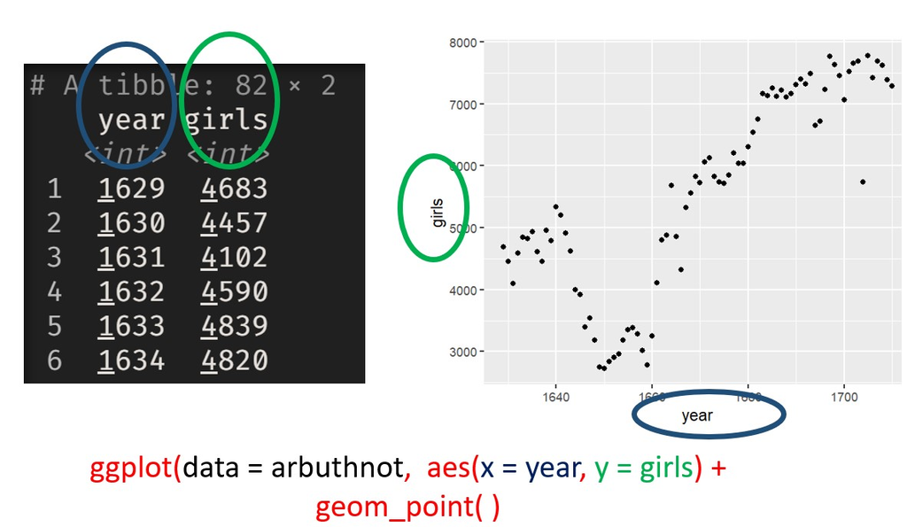

These commands will build a blank plot, with the variables you assigned to the x and y axes. Next, you need to tell `ggplot()` what type of visualization you would like to add to the blank template. You add another layer to the `ggplot()` by:

- adding a `+` at the end of the line, to indicate that you are adding a layer
- then specify the `geom`etric object to be used to create the plot.

Since we want to scatterplot, we use `geom_point()`. This tells `ggplot()` that each data point should be represented by one point on the plot. If you wanted to visualize the above plot using a line graph instead of a scatterplot, you would replace `geom_point()` with `geom_line()`. This tells `ggplot()` to draw a line from each observation with the next observation (sequentially).

```r
ggplot(data = arbuthnot, aes(x = year, y = girls)) +
  geom_line()
```

Use the plot to address the following question:

6. Create the plot and answer the following: is there an apparent trend in the number of girls baptized over the years? How would you describe it?

You might wonder how you are supposed to know the syntax for the `ggplot()` function. Thankfully, `R` documents all of its functions extensively. To learn what a function does and how to use it (e.g. the function’s arguments), just type in a question mark followed by the name of the function that you’re interested in into the console. Type the following in your console:

```r
?ggplot
```

Notice that the help file comes to the forefront, replacing the plot in the lower right panel. You can toggle between the tabs by clicking on their names.

### R as a big calculator

Now, suppose we want to plot the total number of baptisms. To compute this, we could use the fact that we can use `R` as a big calculator. To do this, we can type in mathematical expressions such as the below calculation into the console.

```r
5218 + 4683
```

This calculation would provide us with the total number of baptisms in 1629. We could then repeat this calculation once for each year. This would probably take us a while, but luckily there is a faster way! If we add the vector for baptisms for boys to that of girls, `R` can compute each of these sums simultaneously.

```r
arbuthnot$boys + arbuthnot$girls
```

What you will see is a list of 82 numbers. These numbers appear as a list, because we are working with vectors rather than a data frame. Each number represents the sum of how many boys and girls were baptized that year. You can take a look at the first few rows of the `boys` and `girls` columns to see if the calculation is right.

### Adding variables

We are interested in using this new vector of the total number of baptisms to generate some plots, so we’ll want to save it as a permanent column in our data frame. We can do this using the following code:

```r
arbuthnot <- arbuthnot %>%
  mutate(total = boys + girls)
```

This code has a lot of new pieces to it, so let’s break it down. In the first line we are doing two things, (1) adding a new `total` column to this updated data frame, and (2) overwriting the existing `arbutnot` data frame with an updated data frame that includes the new `total` column.

We are able to chain these two processes together using the **piping** (`%>%`) operator. The piping operator takes the output of the previous expression and “pipes it” into the first argument of the next expression.

To continue our analogy with mathematical functions, `x %>% f(y)` is equivalent to `f(x, y)`. Connecting `arbuthnot` and `mutate(total = boys + girls)` with the pipe operator is the same as typing `mutate(arbuthnot, total = boys + girls)`, where `arbuthnot` becomes the first argument included in the `mutate()` function.

**A note on piping:** Note that we can read these two lines of code as the following:

*“Take the `arbuthnot` dataset and **pipe** it into the `mutate` function. Mutate the `arbuthnot` data set by creating a new variable called `total` that is the sum of the variables called `boys` and `girls`. Then assign the resulting dataset to the object called `arbuthnot`, i.e. overwrite the old `arbuthnot` dataset with the new one containing the new variable.”*

This is equivalent to going through each row and adding up the `boys` and `girls` counts for that year and recording that value in a new column called `total`.

**Where is the new variable?** When you make changes to variables in your dataset, click on the name of the dataset again to update it in the data viewer.

You’ll see that there is now a new column called `total` that has been tacked onto the data frame. The special symbol `<-` performs an *assignment*, taking the output of the piping operations and saving it into an object in your environment. In this case, you already have an object called `arbuthnot` in your environment, so this command updates that data set with the new mutated column.

You can make a line plot of the total number of baptisms per year with the following code:

```r
ggplot(data = arbuthnot, aes(x = year, y = total)) +
  geom_line()
```

In an similar fashion, once you know the total number of baptisms for boys and girls in 1629, you can compute the ratio of the number of boys to the number of girls baptized with the following code:

```r
5218 / 4683
```

Alternatively, you could calculate this ratio for every year by acting on the complete `boys` and `girls` columns, and then save those calculations into a new variable named `boy_to_girl_ratio`:

```r
arbuthnot <- arbuthnot %>%
  mutate(boy_to_girl_ratio = boys / girls)
```

You can also compute the proportion of newborns that are boys in 1629 with the following code:

```r
5218 / (5218 + 4683)
```

Or you can compute this for all years simultaneously and add it as a new variable named `boy_ratio` to the dataset:

```r
arbuthnot <- arbuthnot %>%
  mutate(boy_ratio = boys / total)
```

Notice that rather than dividing by `boys + girls` we are using the `total` variable we created earlier in our calculations!

7. Now, generate a plot of the proportion of boys born over time. What do you see?

**Tip:** If you use the up and down arrow keys in the console, you can scroll through your previous commands, your so-called command history. You can also access your command history by clicking on the history tab in the upper right panel. This can save you a lot of typing in the future.

Finally, in addition to simple mathematical operators like subtraction and division, you can ask R to make comparisons like greater than, `>`, less than, `<`, and equality, `==`. For example, we can create a new variable called `more_boys` that tells us whether the number of births of boys outnumbered that of girls in each year with the following code:

```r
arbuthnot <- arbuthnot %>%
  mutate(more_boys = boys > girls)
```

This command adds a new variable to the `arbuthnot` data frame containing the values of either `TRUE` if that year had more boys than girls, or `FALSE` if that year did not (the answer may surprise you). This variable contains a different kind of data than we have encountered so far. All other columns in the `arbuthnot` data frame have values that are numerical (the year, the number of boys and girls). Here, we’ve asked R to create *logical* data, data where the values are either `TRUE` or `FALSE`. In general, data analysis will involve many different kinds of data types, and one reason for using `R` is that it is able to represent and compute with many of them.

## More Practice

In the previous few pages, you recreated some of the displays and preliminary analysis of Arbuthnot’s baptism data. Your assignment involves repeating these steps, but for present day birth records in the United States. The data are stored in a csv file within the `data` directory. Load the data frame in a similar way to the way we’ve loaded the arbuthnot dataset.

```r
# Here is the way we loaded the arbuthnot dataset
arbuthnot <- read_csv("data/arbuthnot.csv")
# Can you now load the `present` dataset?
```

To find the minimum and maximum values of columns, you can use the functions `min()` and `max()` within a `summarize()` call, which you will learn more about in the following lab.

Here’s an example of how to find the minimum and maximum amount of boy births in a year:

```r
arbuthnot %>%
  summarize(min = min(boys),
            max = max(boys)
            )
```

```r
present %>%
  arrange(desc(total))
```

These data come from reports by the Centers for Disease Control. You can learn more about them by bringing up the help file using the command `?present`.

## More resources

That was a short introduction to R and RStudio, but you can find more resources for learning R and RStudio on the web. Throughout the course we will be using the suite of R packages from the **tidyverse**. The book [R For Data Science](https://r4ds.had.co.nz/) by Grolemund and Wickham is a fantastic resource for data analysis in R with the tidyverse. If you are searching for R code, make sure to also include these package names in your search query. For example, instead of searching “scatterplot in R”, Google “scatterplot in R with the tidyverse”.

These may come in handy throughout the semester:

- [RMarkdown cheatsheet](https://github.com/rstudio/cheatsheets/raw/main/rmarkdown-2.0.pdf)
- [Data transformation cheatsheet](https://github.com/rstudio/cheatsheets/raw/main/data-transformation.pdf)
- [Data visualization cheatsheet](https://github.com/rstudio/cheatsheets/raw/main/data-visualization-2.1.pdf)

Note that some of the code on these cheatsheets may be too advanced for this course. However the majority of it will become useful throughout the semester.

## Acknowledgement

This lab was forked and adapted from the [OpenIntro labs for R and tidyverse](http://openintrostat.github.io/oilabs-tidy/).

This work is licensed under a [Creative Commons Attribution-ShareAlike 4.0 International License](http://creativecommons.org/licenses/by-sa/4.0/).